# DigitRecognition

# 1 Data Prep

The data comes from MIT’s MNIST dataset of hand-written numbers. It lives [here](http://yann.lecun.com/exdb/mnist/)

## 1.1 Test/Train split

```r
set.seed(123)
train <- read.csv("../digits/train.csv", header = T)
dim(train)
```

```
[1] 42000   785
```

```r
subspace.size <-  floor(.1 * nrow(train))
idx <- sample(seq_len(nrow(train)), size = subspace.size)
train <- train[idx,]
dim(train)
```

```
[1] 4200  785
```

```r
# create subspace for faster runtimes
sample.size <- floor(.7 * nrow(train))
idx <- sample(seq_len(nrow(train)), size = sample.size)
train <- train[idx, ]
test <- train[-idx, ]
```

## 1.2 Parallelize

The `caret` package has a feature that allows you to run their models in parallel if you use the following commands.

```r
library(doParallel)
cl <- makePSOCKcluster(8)
registerDoParallel(cl)
```

## 1.3 Save Labels for Later

Here we save the labels to be used as a target later.

```r
train.labels <- (train$label)
test.labels  <- (test$label)
```

## 1.4 Visualize a single number

Below, you can see a single instance of a digit visualized.

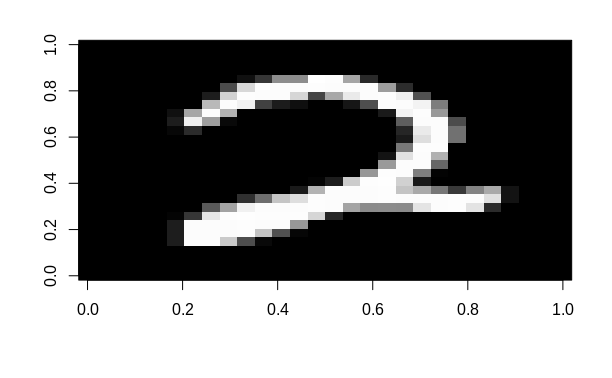

```r
img <- matrix(as.numeric(train[1, -1]), 28, 28)
img <- apply((img), 1, rev)
img <- t(img)
image(img, col = grey(seq(0,1, length=256)))
```

# 2 Scale Test Data

We can use `caret` to clean the data by centering, scaling, and dropping the invariant columns. Additionally, we can have it conduct principal component analysis.

```r
library(caret)
cleaned <-preProcess((train[,-1]), method=c("pca", "nzv", "center" , "scale"))
test.cleaned <- preProcess((test[,-1]), method=c("pca", "nzv", "center" , "scale"))
cleaned <- predict(cleaned, newdata = train[,-1])
test.cleaned <- predict(test.cleaned, newdata = test[,-1])
```

## 2.1 Binning the numbers by label

Here, I bin the numbers so that we can collect eigenvalues of several sets.

```r
digits <- seq(0,9)
train.bins   <- list(0)
test.bins <- list(0)

for (i in 0:9){
  train.idx <- which(train$label == i)
  train.bins[[i + 1]]  <- train[train.idx,]
  train.bins[[i + 1]]$label  <-  NULL
}
for (i in 0:9){
  test.idx <- which(test$label == i)
  test.bins[[i + 1]]  <- test[test.idx,]
  test.bins[[i + 1]]$label  <-  NULL
}
```

# 3 Singular Value Decomposition

```r
calculate <- function(x){
  mtx <- as.matrix(x)
  tmp <- svd(mtx)
  return(tmp)
}

svd.list <- lapply(train.bins, calculate)
#test.svd <- lapply(test.bins, calculate)
```

# 4 Eigen Digits

```
[1] 1
```

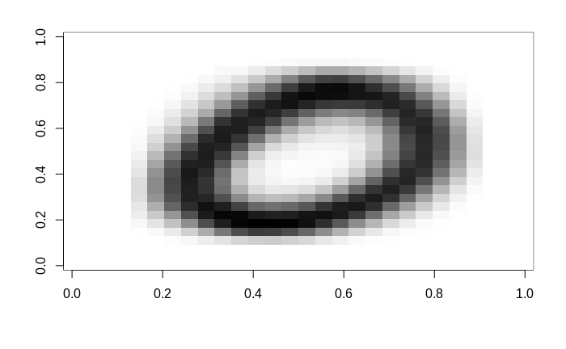

```
[1] 2
```

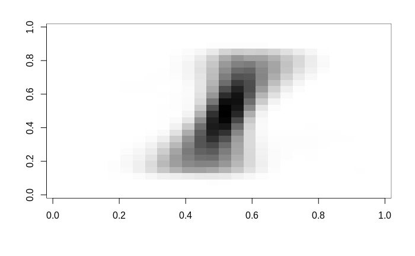

```
[1] 3
```

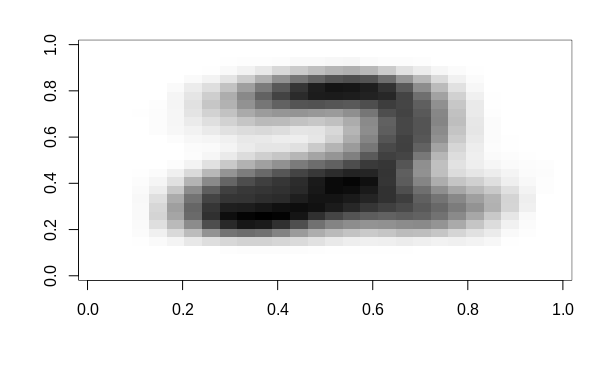

```r
for(i in 1:3){
this <- svd.list
rmtx <- matrix(as.numeric(this[[i]]$v), nrow = 28, ncol = 28)
rmtx <- apply((rmtx), 1, rev)
rmtx <- t(rmtx)
image(rmtx, col = grey(seq(0,1, length=255)))
print(i)
}
```

[Source](https://pdfs.semanticscholar.org/cdab/c8ec5e0629752980f8cb613a56a33efb05c7.pdf)

# 5 Models

## 5.1 Model 1: Naive Bayes

[Complexity](https://stats.stackexchange.com/questions/96995/machine-learning-classifiers-big-o-or-complexity): $O(nm)$

The naive bayes model performs a set of statistics rooted in Bayes Theorem

$$P(A|B) = \frac{P(B|A)P(A)}{P(B)}$$

and assumes the classes are independent of each other. For the cases of singular values, that is necessarily true. For raw data, that independence is does not occur as demonstrated by the above eigen digits.

```r
df <- as.data.frame(cbind(train.labels, cleaned))
train.labels <- as.factor(train.labels)
start_time <- Sys.time()
model1 <- train(cleaned, train.labels, method = "naive_bayes", metric = "Accuracy")
end_time <- Sys.time()
time1 <- end_time - start_time
model1
```

```
Naive Bayes

2940 samples
  90 predictor
  10 classes: '0', '1', '2', '3', '4', '5', '6', '7', '8', '9'

No pre-processing
Resampling: Bootstrapped (25 reps)
Summary of sample sizes: 2940, 2940, 2940, 2940, 2940, 2940, ...
Resampling results across tuning parameters:

  usekernel  Accuracy   Kappa
  FALSE      0.8215217  0.8015320
   TRUE      0.7876174  0.7638238

Tuning parameter 'laplace' was held constant at a value of 0
Tuning parameter 'adjust' was held constant at a value of 1
Accuracy was used to select the optimal model using the largest value.
The final values used for the model were laplace = 0, usekernel = FALSE and adjust = 1.
```

```r
time1
```

```
Time difference of 14.028 secs
```

## 5.2 Model 2: Naive Bayes without PCA

```r
start_time <- Sys.time()
model2 <- train(x = train, y = train.labels, method = "naive_bayes", metric = "Accuracy")
```

[output not shown]

## 5.3 Model 3: Discriminant Analysis

```r
start_time <- Sys.time()
model3 <- train(cleaned, train.labels, method = "pda", metric = "Accuracy", trace = FALSE)
end_time <- Sys.time()
time3 <- end_time - start_time
model3
```

```
Penalized Discriminant Analysis

2940 samples
  90 predictor
  10 classes: '0', '1', '2', '3', '4', '5', '6', '7', '8', '9'

No pre-processing
Resampling: Bootstrapped (25 reps)
Summary of sample sizes: 2940, 2940, 2940, 2940, 2940, 2940, ...
Resampling results across tuning parameters:

  lambda  Accuracy   Kappa
  0e+00   0.8285874  0.8092643
  1e-04   0.8285874  0.8092643
  1e-01   0.8285874  0.8092643

Accuracy was used to select the optimal model using the largest value.
The final value used for the model was lambda = 0.
```

```r
time3
```

```
Time difference of 4.810693 secs
```

```r
start_time <- Sys.time()
model3b <- train(cleaned, train.labels, method = "pda", metric = "Accuracy", trace = FALSE, pcaComp = 200)
end_time <- Sys.time()
time3b <- end_time - start_time
model3b
```

```
Penalized Discriminant Analysis

2940 samples
  90 predictor
  10 classes: '0', '1', '2', '3', '4', '5', '6', '7', '8', '9'

No pre-processing
Resampling: Bootstrapped (25 reps)
Summary of sample sizes: 2940, 2940, 2940, 2940, 2940, 2940, ...
Resampling results across tuning parameters:

  lambda  Accuracy   Kappa
  0e+00   0.8263015  0.8067153
  1e-04   0.8263015  0.8067153
  1e-01   0.8263015  0.8067153

Accuracy was used to select the optimal model using the largest value.
The final value used for the model was lambda = 0.
```

```r
time3b
```

```
Time difference of 4.601261 secs
```

```r
start_time <- Sys.time()
model3c <- train(cleaned, train.labels, method = "pda", metric = "Accuracy", trace = FALSE, pcaComp = 20)
end_time <- Sys.time()
time3c <- end_time - start_time
model3c
```

```
Penalized Discriminant Analysis

2940 samples
  90 predictor
  10 classes: '0', '1', '2', '3', '4', '5', '6', '7', '8', '9'

No pre-processing
Resampling: Bootstrapped (25 reps)
Summary of sample sizes: 2940, 2940, 2940, 2940, 2940, 2940, ...
Resampling results across tuning parameters:

  lambda  Accuracy   Kappa
  0e+00   0.8293077  0.8100901
  1e-04   0.8293077  0.8100901
  1e-01   0.8293077  0.8100901

Accuracy was used to select the optimal model using the largest value.
The final value used for the model was lambda = 0.
```

```r
time3c
```

```
Time difference of 4.622785 secs
```

# 6 Discriminant Analysis without PCA

```r
start_time <- Sys.time()
model4 <- suppressWarnings(train(train, train.labels, method = "pda", metric = "Accuracy", trace = FALSE))
```

[output not shown]

# 7 Neural Nets with PCA

Neural nets use a network of weighted sigmoid functions to approximate a multivariable surface. The math is fairly involved and outside the scope of this paper. However, they are known to be highly accurate across a wide set of data. That is not true in our case, perhaps due to overfitting in the training stage.

```r
start_time <- Sys.time()
model5 <- suppressWarnings(train(cleaned, train.labels, method = "nnet", metric = "Accuracy", trace = FALSE))
end_time <- Sys.time()
time5 <- end_time - start_time
pred5 <- predict(model5, test.cleaned)
accuracy5 <- sum(pred5 == test.labels)/length(test.labels)
accuracy5
```

```
[1] 0.01002227
```

```r
time5
```

```
Time difference of 2.215682 mins
```

Additionally, the training time of the neural network is measured in minutes. An additional downside is that adding real-time data requires backpropagation and adds to run time complexity.

# 8 Neural Nets without PCA

```r
start_time <- Sys.time()
model6 <- train(train[1:100,], train.labels[1:100], method = "nnet", metric = "Accuracy", trace = FALSE, MaxNWts = 5000)
end_time <- Sys.time()
time6 <- end_time - start_time
pred6 <- predict(model6, test)
accuracy6 <- sum(pred6 == test.labels)/length(test.labels)
accuracy6
```

```
[1] 0.2951002
```

```r
time6
```

```
Time difference of 12.52918 mins
```

```r
start_time <- Sys.time()
model7 <- train(train[1:100,], train.labels[1:100], method = "pcaNNet", metric = "Accuracy", trace = FALSE, MaxNWts = 5000)
end_time <- Sys.time()
time7 <- end_time - start_time
pred7 <- predict(model6, test)
accuracy7 <- sum(pred6 == test.labels)/length(test.labels)
accuracy7
time7
```

[output not shown]

# 9 Conclusion

Using matrix decomposition allows for faster processing of the categories. This system works about as well as the previous models given that the range is 2 * as big (10 classes rather than the 5 in the MovieLense data). The neural networks were curiously very, very bad at modelling this data for some unexplained reason, but we were still able to measure and compare run times reliably. Dependending on the particular model, principle component analysis can increase or decrease the accuracy score, but it always reduces the run time. In general, we could increase the numbers of components beyond the tested 90 with a linear increase in run-time requirements in exchange for a more accurate prediction. This could prove to be a net improvement in run-time, but a very particular configuration would be necessary. Linear discriminant analysis without or without principal component analysis proved to be the best model. The particular choice depends on requisite accuracy and the compute architecture of the system running the model. Spark would only be appropriate on the order of Petabytes as a way to pre-train models before deploying them on embedded systems. However, linear operations like linear discriminant analysis and principal component analsysis can severely decrese runtime memory and run-time requirements.

## 9.1 Video

[Is here](https://www.loom.com/share/7e13dc98ee164b2c952bf5b7742b74a6)